# Exercise solution for Chapter 2, Part 2

Sarah Cooper

2020-02-24

# Exercise 2.6

The first part of the exercise asks you to:

> Choose your own prior for the parameters of the beta distribution. You can do this by sketching it here: https://jhubiostatistics.shinyapps.io/drawyourprior.

After sketching a plot, I chose the parameters to set up a prior: $\alpha$ = 2.47 and $\beta$ = 8.5.

# Using this prior

Next, the exercise asks you:

> Once you have set up a prior, re-analyse the data from Section 2.9.2, where we saw Y = 40 successes out of n = 300 trials.

To be able to use the `loglikelihood` function from the text, I first needed to redefine it here:

```r
loglikelihood = function(theta, n = 300, k = 40) { ## Function definition from the textbook
  log(choose(n, k)) + k * log(theta) + (n - k) * log(1 - theta)
}
```

Then, I created a vector of $\theta$ values between 0 and 1, spaced 0.001 units wide. The plot below shows different possible values of $\theta$ and the log likelihood for each of these values:

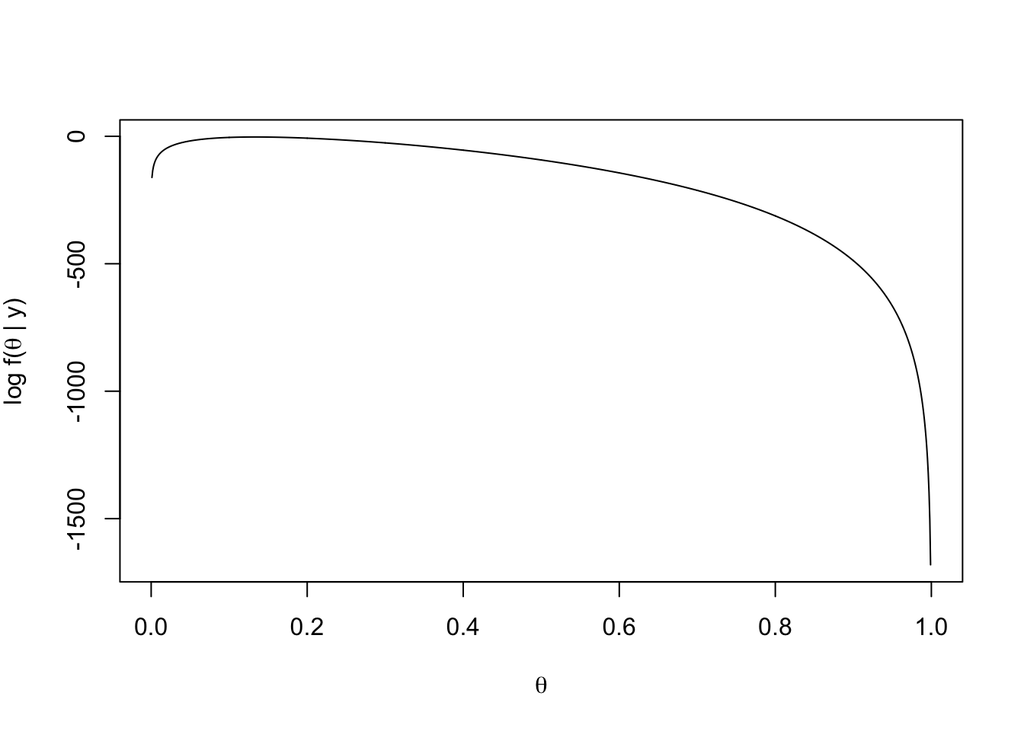

```r
thetas = seq(0, 1, by = 0.001)
plot(thetas, loglikelihood(thetas), xlab = expression(theta),
     ylab = expression(paste("log f(", theta, " | y)")),type = "l")
```

Next, I used `rbeta` to draw 1,000,000 random samples from a beta distribution with my new picks for the parameters for $\alpha$ and $\beta$:

```r
rtheta = rbeta(1000000, shape1 = 2.47, shape2 = 8.5)
```

After running the above, for each of these $\theta$ values, we then generate a random sample of $Y$ as observed in the histogram (with orange bars):

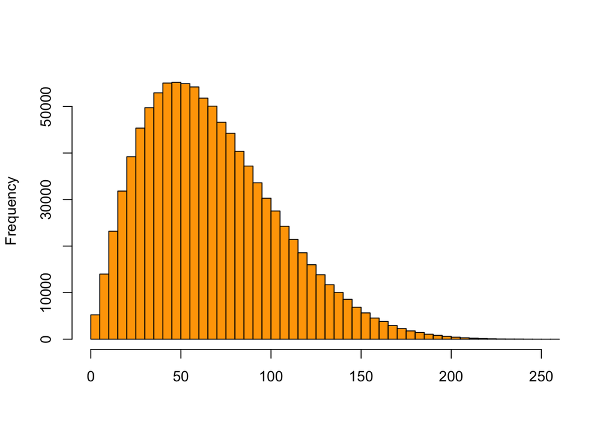

```r
y = vapply(rtheta, function(th) {
  rbinom(1, prob = th, size = 300)
}, numeric(1))
hist(y, breaks = 50, col = "orange", main = "", xlab = "")
```

Our next step is to use this information to generate a posterior distribution of $\theta$ at a fixed $Y$ value. In this example they used $Y=40$.

After running the above, for each of these thetas, we generated simulated values for the posterior distribution of $\theta$ at $Y=40$ as observed in this histogram (with green bars).

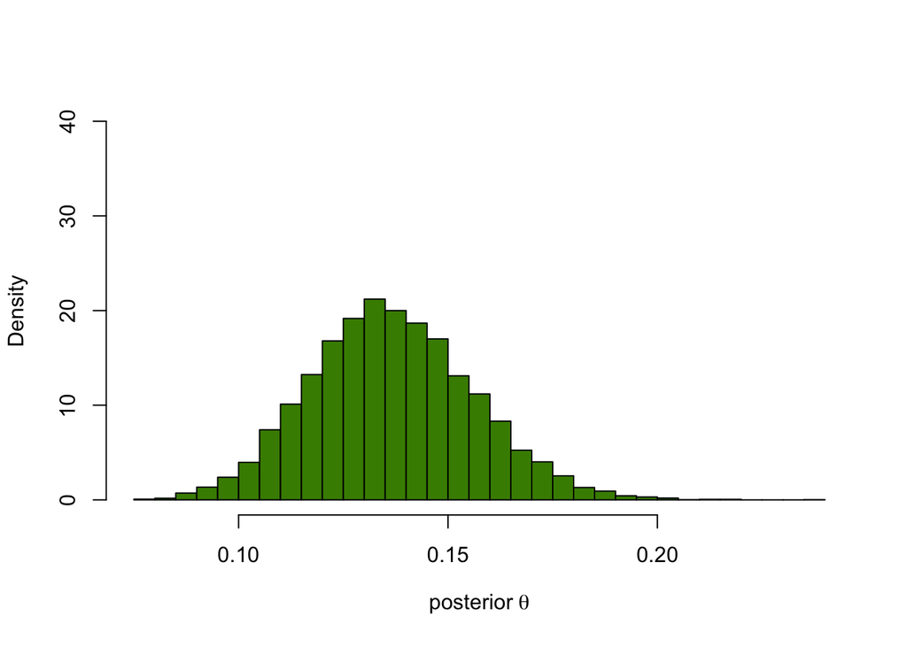

```r
thetaPostEmp = rtheta[ y == 40 ]
hist(thetaPostEmp, breaks = 40, col = "chartreuse4", main = "",
     probability = TRUE, xlab = expression("posterior"~theta), ylim=c(0,40))
```

```r
densPostTheory  =  dbeta(thetas, 42.47, 268.5)
```

You can check how this compares to the theoretical posterior distribution for $\theta$ at $Y = 40$:

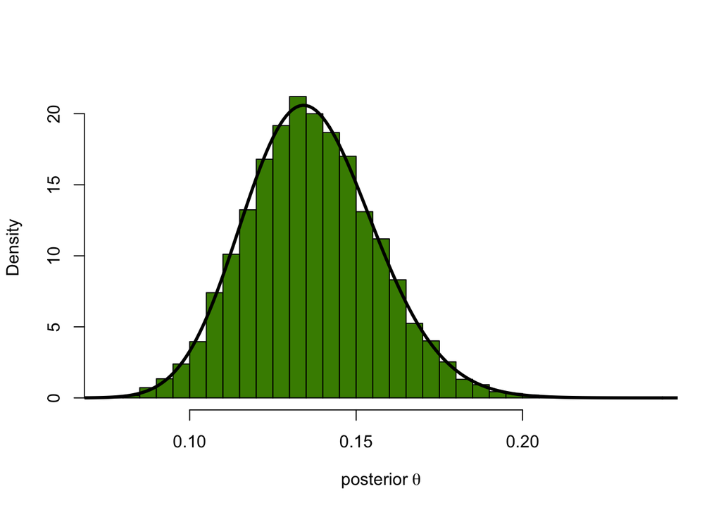

```r
hist(thetaPostEmp, breaks = 40, col = "chartreuse4", main = "",
  probability = TRUE, xlab = expression("posterior"~theta))
lines(thetas, densPostTheory, type="l", lwd = 3)
```

We can also check the means of both distributions computed above.

```r
mean(thetaPostEmp) # Empirical
```

```
## [1] 0.136646
```

```r
dtheta = thetas[2]-thetas[1]
sum(thetas * densPostTheory * dtheta) # Theoretical
```

```
## [1] 0.1365727
```

## Monte Carlo integration

We can use Monte Carlo integration instead and then check the agreement between our Monte Carlo sample `thetaPostMC` and our sample `thetaPostEmp` with a QQ plot:

```r
thetaPostMC = rbeta(n = 1e6, 42.47, 268.5)
mean(thetaPostMC)
```

```
## [1] 0.136562
```

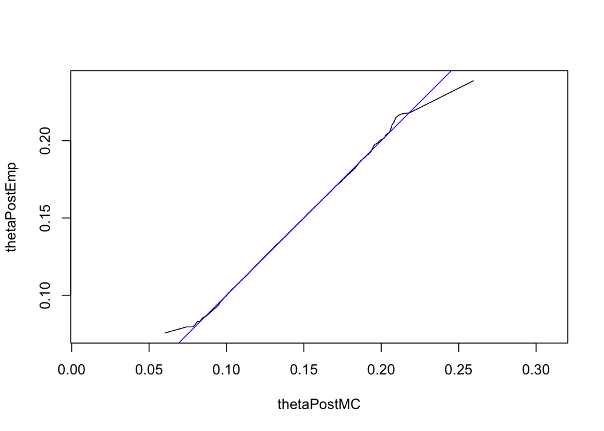

```r
qqplot(thetaPostMC, thetaPostEmp, type = "l", asp = 1)
abline(a = 0, b = 1, col = "blue")
```

```r
densPost2 = dbeta(thetas, 42.47, 268.5)
mcPost2   = rbeta(1e6, 42.47, 268.5)
sum(thetas * densPost2 * dtheta)  # mean, by numeric integration
```

```
## [1] 0.1365727
```

```r
mean(mcPost2)                     # mean, by MC
```

```
## [1] 0.1365751
```

```r
thetas[which.max(densPost2)]      # MAP estimate
```

```
## [1] 0.134
```

```r
quantile(mcPost2, c(0.025, 0.975))
```

```
##      2.5%     97.5%
## 0.1007631 0.1768072
```